# SCPython1

### SciPython/Practical_classes_1

### Linear algebra

```python
import numpy as np
```

```python
#let's define a vector v

v = np.array([3,0,-4])
print(v)
```

```
[ 3  0 -4]
```

```python
#length of the vector

len_v = np.linalg.norm(v)
print(len_v)
```

```
5.0
```

```python
#operations on vectors

v1 = np.array([1,2,5])
v2 = np.array([-5,0,-1])

print(v1+v2, v1-v2, v1*v2, 3*v1)
```

```
[-4  2  4] [6 2 6] [-5  0 -5] [ 3  6 15]
```

```python
#dot product
print(np.dot(v1,v2))
```

```
-10
```

```python
np.outer(v1, v2)  #v1*v2T, sometimes works better than np.dot, especially when we multiply a matrix by vector
```

```
array([[ -5,   0,  -1],
       [-10,   0,  -2],
       [-25,   0,  -5]])
```

```python
#linear dependence

a = np.array([8, 1, 4])
b = np.array([1,7,8])
c = np.array([2,3,4])

a == -2*b+5*c #a = -2*b + 5*c?? works for integers ;-)
```

```
array([ True,  True,  True])
```

### Exercise 1

Define a function that takes two vectors and computes the cosine of the angle between them (cosine similarity).

The cosine similarity between two vectors $x$ and $y$ is defined as:

$$ \cos(\theta) = \frac{x \cdot y}{\|x\|\|y\|} $$

where:

- $x \cdot y$ — dot product of vectors
- $\|x\|$ — Euclidean norm of vector $x$
1. Implement a function that computes cosine similarity between two vectors.
2. Check whether the vectors

$$ x_1 = [3, 1, -2, 4], \quad x_2 = [-1, 3, 4, 2] $$

are orthogonal.

1. Consider the following feature vectors:

$$ x_1 = [3,1,-2,4] $$$$ x_2 = [-1,3,4,2] $$$$ x_3 = [2,0,-1,3] $$$$ x_4 = [-2,4,3,1] $$$$ x_5 = [1,1,-1,2] $$

Each coordinate represents a feature describing an object.

- Compute cosine similarity for **all pairs of vectors**.
- Determine **which pair of objects is the most similar**.
- Determine **which pair of objects is the least similar**.
- Identify pairs of vectors that are **orthogonal or nearly orthogonal**.

```python
#matrices
A = np.array([[2,3],[1,2]]); B = np.array([[1,1], [2,3]])
print(A)
print()
print(B)
```

```
[[2 3]
 [1 2]]

[[1 1]
 [2 3]]
```

```python
print(A[:,0]) #first column of A
```

```
[2 1]
```

```python
print(np.mean(A, axis = 0)) #means by columns, axis =1 <-- by rows
```

```
[1.5 2.5]
```

```python
print(np.transpose(A))
```

```
[[2 1]
 [3 2]]
```

```python
print(A+B)
```

```
[[3 4]
 [3 5]]
```

```python
print(np.dot(A,B)) #A*B
```

```
[[ 8 11]
 [ 5  7]]
```

```python
print(np.linalg.det(A)) #determinant of a matrix
```

```
1.0
```

```python
#inverse of a matrix
A_inv = np.linalg.inv(A)

print(A_inv)
```

```
[[ 2. -3.]
 [-1.  2.]]
```

### Exercise 2

Check whether the matrix above is in fact, the inverse of $A$ by calculating $A\cdot A^{-1}$. What should you obtain?

### Exercise 3

Define two square matrices $A$ and $B$ and calculate $A\cdot B+B^T$.

$$A = \begin{bmatrix} 1 & 2 & 1 \\ 3 & 0 & 1 \\ 0 & 2 & 4 \end{bmatrix}$$

, $$B = \begin{bmatrix} -1 & 0 & 1 \\ 2 & 1 & 0 \\ 3 & -2 & 1 \end{bmatrix}$$

### Simple plots

```python
import matplotlib.pyplot as plt
```

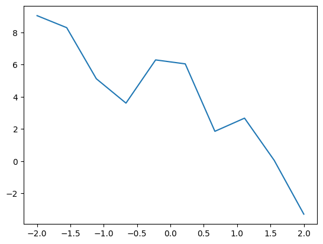

```python
#simple plots (continuous line)
x = np.linspace(-2,2,10) #domain, from -2 to 2, 10 numbers
y = -3*x+4+ np.random.normal(0, 2, 10)         #function

plt.plot(x,y)
plt.show()
```

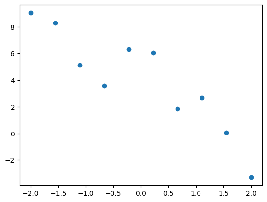

```python
#simple plots (scattter plot)
plt.scatter(x,y)
plt.show()
```

```python
np.cov(x,y) #covariance matrix for variables X and Y
```

```
array([[ 1.81069959, -4.60231119],
       [-4.60231119, 14.41779595]])
```

### Exercise 4

For the example above, what is the covariance between $X$ and $Y$, i.e. $cov(X,Y)$?. Using the covariance matrix, calculate the correlation coefficient. Interpret it.

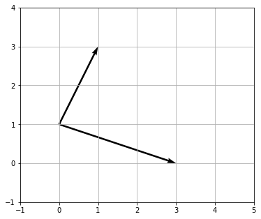

```python
#vectors on a plane

X = np.array([0,0])
Y= np.array([1,1])
U = np.array([1,3])
V = np.array([2,-1])

fig, ax = plt.subplots(figsize=(6, 6))
ax.quiver(X, Y, U, V, units='xy' ,scale=1)
ax.grid()
plt.xlim(-1,5)
plt.ylim(-1,4)
ax.set_aspect('equal')
plt.show()
```

### Exercise 5

To rotate a vector $v$ one may multiply the matrix $$A = \begin{bmatrix} \cos \theta & \sin \theta \\ -\sin \theta & \cos \theta \end{bmatrix}$$ by it (i.e. $Av$), where $\theta$ is an angle of rotation.

- Define a vector $[-3,4]$ which starts in the origin of coordiantes. Rotate it ($\theta = 30^o$) and plot both vectors.

### Probability

```python
import statistics
print(dir(statistics))
```

```
['Counter', 'Decimal', 'Fraction', 'LinearRegression', 'NormalDist', 'StatisticsError', '_SQRT2', '__all__', '__annotations__', '__builtins__', '__cached__', '__doc__', '__file__', '__loader__', '__name__', '__package__', '__spec__', '_coerce', '_convert', '_decimal_sqrt_of_frac', '_exact_ratio', '_…
```

Normal distribution is very often used to model some features. It has two parameters $\mu$ and $\sigma$ and PDF is given by $f(x) = \frac{1}{\sigma \sqrt{2 \pi}}\cdot e^{-\frac{(x-\mu)^2}{2\sigma^2}}$

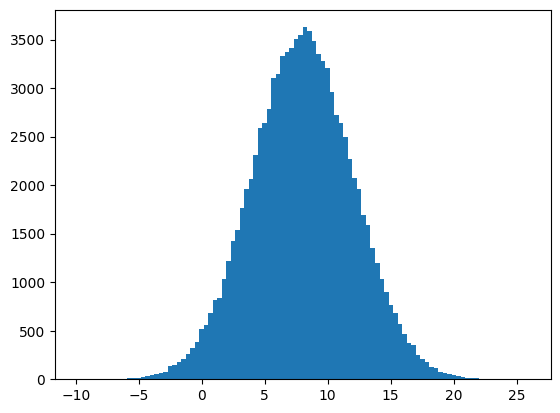

```python
y = np.random.normal(8, 4, 100000) #generate 10K numbers from N(8,4)

plt.hist(y, bins = 100)
plt.show()
```

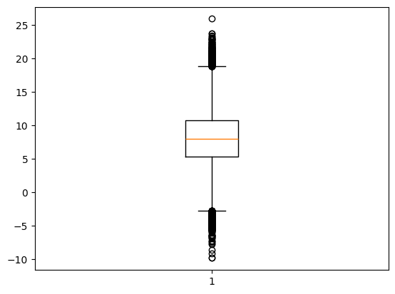

```python
#boxplot
plt.boxplot(y)
plt.show()
```

```python
statistics.mean(y), statistics.stdev(y) #mean and standard deviation
```

```
(np.float64(8.003987465452115), 4.003896883005009)
```

```python
statistics.median(y) #median
```

```
np.float64(8.01116937791586)
```

```python
statistics.quantiles(y) #quantiles
```

```
[np.float64(5.301795686111676),
 np.float64(8.01116937791586),
 np.float64(10.708139824076847)]
```

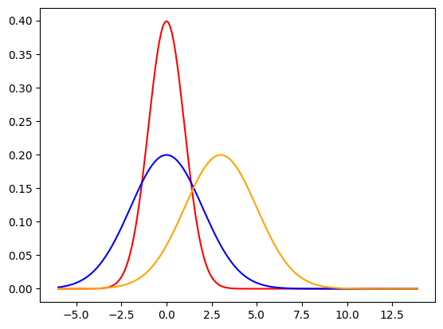

```python
from math import pi, e

def f(x, mu = 0, sigma = 1):
    return (1/(sigma*(2*pi)**0.5))*e**(-((x-mu)**2)/(2*sigma**2))

x = [-6+0.1*i for i in range(200)]

y1 = [f(elem) for elem in x]  #N(0,1)
y2 = [f(elem, sigma = 2) for elem in x]   #N(0,2)
y3 = [f(elem, mu=3, sigma = 2) for elem in x]  #N(3,2)

plt.plot(x,y1, c = "red")
plt.plot(x,y2, c = "blue")
plt.plot(x,y3, c = "orange")
plt.show()
```

#### CDF: $F(t) = P(X \leq t)$

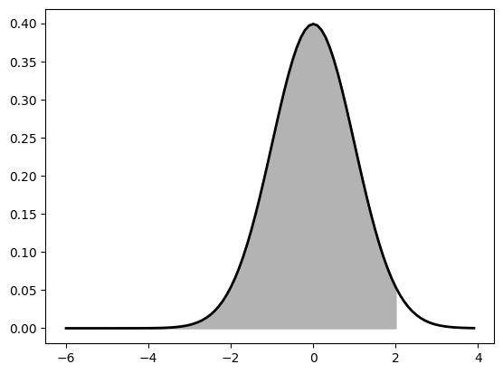

```python
def f(x, mu = 0, sigma = 1):
    return (1/(sigma*(2*pi)**0.5))*e**(-((x-mu)**2)/(2*sigma**2))

x = [-6+0.1*i for i in range(100)]
y1 = [f(elem) for elem in x]  #N(0,1)

plt.plot(x,y1, "k-", lw=2)

z = np.linspace(0 - 4*1, 2,100)
plt.fill_between(z,0, f(z), color = "0.7")
plt.show()
```

```python
from scipy.stats import norm

print(norm.cdf(2)) #F(2) for X~N(0,1)
```

```
0.9772498680518208
```

```python
help(norm.cdf)
```

```
Help on method cdf in module scipy.stats._distn_infrastructure:

cdf(x, *args, **kwds) method of scipy.stats._continuous_distns.norm_gen instance
    Cumulative distribution function of the given RV.

    Parameters
    ----------
    x : array_like
        quantiles
    arg1, arg2, arg3,... : array_like
        The shape parameter(s) for the distribution (see docstring of the
        instance object for more information)
    loc : array_like, optional
        location parameter (default=0)
    scale : array_like, optional
        scale parameter (default=1)

    Returns
    -------
    cdf : ndarray
        Cumulative distribution function evaluated at `x`
```

```python
print(norm.cdf(2, loc =1, scale = 3)) #F(2) for X~N(1,3)
```

```
0.6305586598182363
```

### Exercise 6

Given a random variable $X \sim N(0,1)$ calculate $P(X<1)$, $P(X>1)$ and $P(-1<X<2)$.

### Exercise 7

Suppose in a given population the height may be described as a random variable $X \sim N(170, 10)$.

- What is the percent of people who have the height between 160 and 190?

### Exercise 8

A company is analyzing emails to determine the probability that a given email is spam if it contains the word "win". It collected the following data:

```python
d = [('NS', False), ('NS', False), ('S', False), ('NS', False), ('NS', True), ('NS', False), ('S', False), ('NS', False), ('NS', False), ('NS', False), ('NS', False), ('S', True), ('NS', False), ('NS', False), ('S', True), ('NS', False), ('NS', False), ('NS', False), ('NS', True), ('S', True), ('NS', False), ('NS', False), ('S', True), ('NS', False), ('NS', False), ('NS', False), ('NS', False), ('NS', False), ('NS', True), ('NS', False), ('S', True), ('NS', False), ('S', False), ('S', True), ('NS', False), ('S', True), ('S', True), ('NS', False), ('NS', False), ('NS', False), ('NS', False), ('NS', False), ('NS', False), ('NS', False), ('NS', False), ('NS', False), ('NS', False), ('NS', False), ('NS', False), ('S', True), ('NS', False), ('NS', False), ('NS', False), ('NS', False), ('NS', False), ('NS', False), ('NS', False), ('NS', False), ('S', False), ('S', False), ('NS', False), ('NS', True), ('NS', False), ('NS', False), ('NS', False), ('NS', False), ('S', True), ('S', False), ('NS', False), ('NS', False), ('NS', True), ('NS', False), ('NS', False), ('NS', True), ('NS', False), ('NS', False), ('NS', False), ('NS', False), ('S', True), ('NS', False), ('NS', False), ('NS', False), ('NS', True), ('S', True), ('NS', False), ('S', False), ('S', False), ('NS', False), ('NS', False), ('NS', False), ('NS', True), ('NS', False), ('NS', False), ('NS', False), ('NS', False), ('NS', False), ('NS', False), ('NS', False), ('NS', False), ('NS', False)]
print(d)
```

```
[('NS', False), ('NS', False), ('S', False), ('NS', False), ('NS', True), ('NS', False), ('S', False), ('NS', False), ('NS', False), ('NS', False), ('NS', False), ('S', True), ('NS', False), ('NS', False), ('S', True), ('NS', False), ('NS', False), ('NS', False), ('NS', True), ('S', True), ('NS', Fa…
```

Based on the data, determine:

- the probability an email is spam $P(S)$
- the probability of containing a word "win" provided a message is a spam $P("win"|S)$
- the probability of containing a word "win" provided a message is not a spam $P("win"|NS)$

What is the probability that an email is a spam, given that it contains the word "win"? $P(S|"win")$. Calculate it directly and by using Bayesian Theorem.

#### Bayesian approach

Let's assume we observe a random variable $X$ in two groups $L_1$ and $L_2$. According to the Bayesian Theorem

$P(L_1|X) = \frac{P(X|L_1)P(L_1)}{P(X)}$ and $P(L_2|X) = \frac{P(X|L_2)P(L_2)}{P(X)}$

The higher the probability $P(L_i|X)$ is, the more prone we are to consider $L_i$ as a proper group. By investigating the ratio

$\frac{P(L_1|X)}{P(L_2|X)}$

which is

$\frac{P(X|L_1)P(L_1)}{P(X|L_2)P(L_2)}$

one may determine the most probable choice.

Based on the training data, we approximate the probabilities $P(X|L_i)$ and $P(L_i)$. To calculate $P(X|L_i)$, in praxctice, we usually need to assume the distribution function; for continuous random variables we put density function here.

### Exercise 9

Consider the following height data in two populations - $P_1$ and $P_2$.

```python
data = [('p1', 178.46), ('p1', 171.58), ('p2', 152.96), ('p2', 148.92), ('p1', 195.19), ('p2', 150.78), ('p1', 176.33), ('p1', 167.77), ('p2', 157.42), ('p1', 158.5), ('p2', 154.23), ('p1', 164.32), ('p1', 170.9), ('p1', 175.8), ('p1', 174.4), ('p2', 158.17), ('p1', 161.3), ('p1', 189.98), ('p1', 166.66), ('p1', 177.61), ('p1', 166.0), ('p2', 154.7), ('p1', 166.15), ('p2', 161.93), ('p2', 157.65), ('p1', 162.41), ('p1', 166.94), ('p1', 153.97), ('p1', 161.03), ('p1', 168.84), ('p1', 178.26), ('p2', 164.13), ('p2', 154.79), ('p1', 166.99), ('p1', 165.03), ('p1', 165.24), ('p1', 186.21), ('p1', 181.89), ('p1', 160.76), ('p1', 181.06), ('p1', 179.48), ('p2', 157.88), ('p2', 156.49), ('p2', 163.57), ('p2', 158.5), ('p1', 173.76), ('p1', 156.87), ('p1', 189.63), ('p2', 168.45), ('p2', 160.94), ('p1', 169.36), ('p2', 159.43), ('p2', 159.43), ('p1', 166.24), ('p2', 163.98), ('p2', 142.77), ('p1', 171.57), ('p1', 192.71), ('p2', 168.96), ('p1', 155.96), ('p2', 143.28), ('p2', 182.12), ('p2', 144.3), ('p1', 169.13), ('p1', 176.34), ('p2', 154.05), ('p1', 175.59), ('p1', 160.09), ('p1', 159.16), ('p1', 159.5), ('p2', 148.88), ('p2', 144.91), ('p1', 180.93), ('p2', 165.41), ('p2', 151.08), ('p1', 173.76), ('p1', 163.51), ('p2', 166.51), ('p2', 148.07), ('p1', 159.95), ('p1', 165.78), ('p1', 168.66), ('p1', 174.13), ('p1', 162.41), ('p2', 138.7), ('p1', 173.14), ('p2', 143.03), ('p1', 159.47), ('p2', 139.14), ('p1', 158.82), ('p2', 147.73), ('p2', 160.3), ('p1', 160.0), ('p1', 188.51), ('p1', 161.37), ('p1', 169.68), ('p2', 155.67), ('p2', 157.35), ('p1', 149.62), ('p1', 183.45), ('p1', 173.27), ('p2', 146.69), ('p1', 171.13), ('p2', 163.92), ('p2', 169.85), ('p2', 159.29), ('p1', 170.31), ('p2', 173.83), ('p2', 162.65), ('p1', 169.83), ('p1', 173.21), ('p2', 181.41), ('p1', 176.2), ('p2', 161.09), ('p1', 174.23), ('p1', 167.77), ('p1', 167.04), ('p1', 160.95), ('p2', 162.47), ('p2', 164.4), ('p2', 174.46), ('p1', 169.89), ('p1', 155.88), ('p2', 151.6), ('p1', 168.04), ('p2', 173.8), ('p1', 192.41), ('p1', 161.99), ('p2', 155.73), ('p2', 157.97), ('p1', 153.93), ('p1', 173.21), ('p2', 150.26), ('p1', 181.24), ('p2', 160.81), ('p1', 150.65), ('p2', 163.86), ('p1', 173.39), ('p1', 153.41), ('p2', 150.77), ('p2', 153.46), ('p1', 177.17), ('p2', 170.38), ('p1', 160.57), ('p1', 147.83), ('p2', 138.39), ('p2', 153.98), ('p2', 145.62), ('p2', 168.29), ('p2', 153.45), ('p2', 162.17), ('p1', 175.83), ('p1', 178.8), ('p2', 159.27), ('p1', 174.79), ('p2', 156.27), ('p2', 156.64), ('p1', 175.39), ('p1', 169.8), ('p2', 149.33), ('p2', 182.76), ('p2', 158.84), ('p1', 175.01), ('p1', 175.41), ('p2', 156.73), ('p1', 166.13), ('p1', 173.1), ('p2', 140.1), ('p2', 165.41), ('p1', 179.24), ('p2', 174.09), ('p1', 155.33), ('p2', 160.75), ('p1', 171.18), ('p2', 168.74), ('p1', 163.51), ('p1', 175.81), ('p1', 163.63), ('p2', 160.77), ('p2', 153.78)]
print(data)
```

```
[('p1', 178.46), ('p1', 171.58), ('p2', 152.96), ('p2', 148.92), ('p1', 195.19), ('p2', 150.78), ('p1', 176.33), ('p1', 167.77), ('p2', 157.42), ('p1', 158.5), ('p2', 154.23), ('p1', 164.32), ('p1', 170.9), ('p1', 175.8), ('p1', 174.4), ('p2', 158.17), ('p1', 161.3), ('p1', 189.98), ('p1', 166.66), …
```

Assume in both populations the height follows the normal distribtuion.

- estitmate distributions parameters (based ond means and standard deviations)
- determine to which group (more likely) a person who has 160 belongs to
- determine to which group (more likely) a person who has 165 belongs to
- determine to which group (more likely) a person who has 173 belongs to

#### 3D Plots

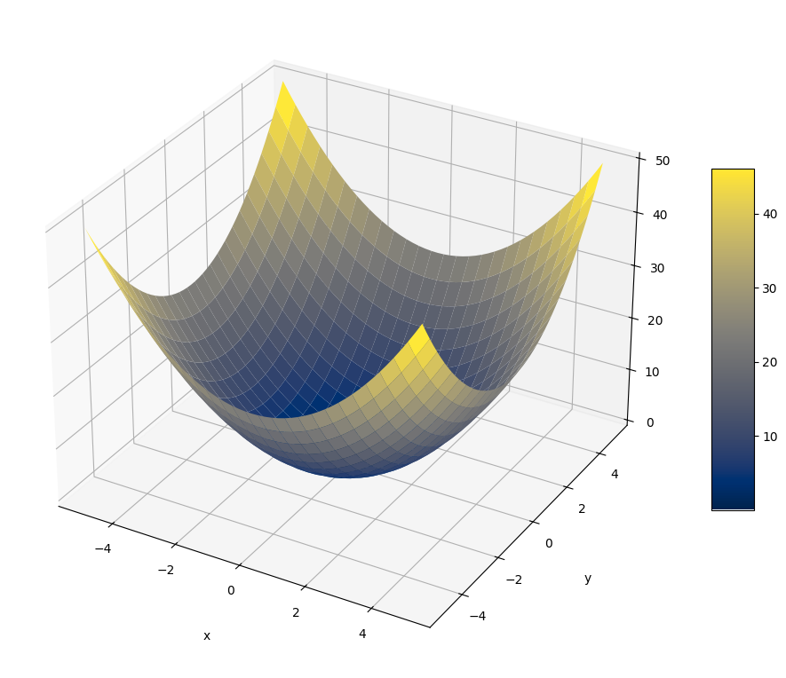

```python
fig = plt.figure(figsize = (12,10))
ax = plt.axes(projection='3d')

x = np.arange(-5, 5.1, 0.2)
y = np.arange(-5, 5.1, 0.2)

X, Y = np.meshgrid(x, y)
Z = X**2 + Y**2

surf = ax.plot_surface(X, Y, Z, cmap = plt.cm.cividis)

ax.set_xlabel('x', labelpad=20)
ax.set_ylabel('y', labelpad=20)
ax.set_zlabel('z', labelpad=20)

fig.colorbar(surf, shrink=0.5, aspect=8)

plt.show()
```

### Multivariate normal distribution

### Exercise10

- Define a PDF for 2D normal distribution given by $f(X) = \frac{1}{2\pi\sqrt{\det(\Sigma)}}\cdot \exp(-\frac{1}{2}(X-\mu)^T\Sigma^{-1}(X-\mu))$, where $X = [X_1, X_2]$, $\mu = [\mu_1,\mu_2]$ and $\Sigma$ is a covariance matrix. Both $\mu$ and $\Sigma$ are parameters.
- Assuming $\mu=[1,2]$ and $$\Sigma = \begin{bmatrix} 1 & 1.1 \\ 1.1 & 4 \end{bmatrix}$$ Calculate $f(0,1)$.

### Exercise11

Below is a two-dimensional dataset (two features).

- Estimate the mean vector $\mu$ and covariance matrix $\Sigma$.
- Plot the probability density function (PDF) of the distribution.

Hint: You may apply the function defined in the previous exercises or use

from scipy.stats import multivariate_normal

https://docs.scipy.org/doc/scipy-1.17.0/reference/generated/scipy.stats.multivariate_normal.html

```python
df = [[7.4, 13.1], [9.3, 12.5], [6.7, 21.0], [11.9, 11.2], [8.2, 11.1], [6.9, 11.7], [5.2, 17.3], [9.7, 7.3], [5.0, 13.2], [6.2, 14.1], [7.1, 17.6], [5.5, 13.0], [9.0, 9.8], [10.7, 14.5], [7.0, 14.6], [5.7, 18.2], [9.8, 16.5], [7.6, 16.4], [7.1, 15.6], [5.5, 12.9], [9.0, 11.9], [6.7, 15.0], [5.8, 21.5], [5.4, 13.6], [8.9, 14.2], [7.9, 13.6], [7.1, 13.0], [13.2, 12.1], [8.7, 10.7], [4.4, 13.1], [7.6, 19.4], [9.7, 9.4], [6.6, 16.8], [8.9, 18.1], [9.9, 12.0], [9.0, 10.2], [8.1, 14.3], [10.2, 12.0], [8.8, 9.1], [5.2, 16.5], [10.1, 16.1], [10.1, 15.0], [9.0, 9.6], [6.1, 13.8], [8.9, 12.8], [7.3, 14.2], [9.7, 8.2], [9.9, 9.9], [7.9, 13.8], [6.8, 10.0], [6.0, 18.2], [8.3, 13.0], [11.9, 11.1], [8.9, 11.8], [8.4, 16.0], [6.4, 13.1], [8.4, 16.4], [7.1, 17.8], [5.2, 20.2], [9.6, 15.5], [7.8, 19.7], [9.3, 14.4], [6.6, 17.1], [7.7, 10.8], [8.8, 15.8], [7.5, 12.1], [9.0, 12.6], [7.4, 16.5], [10.1, 15.1], [4.1, 21.9], [4.6, 18.1], [5.1, 16.7], [8.5, 12.9], [8.0, 7.0], [11.3, 12.6], [9.8, 14.0], [10.9, 9.5], [5.9, 14.5], [3.4, 18.4], [12.2, 15.2], [8.4, 10.8], [5.7, 13.4], [4.5, 14.1], [10.2, 15.1], [7.0, 15.8], [8.3, 13.0], [9.0, 13.5], [7.3, 16.0], [7.8, 16.4], [6.2, 8.6], [7.1, 14.2], [10.3, 15.9], [8.9, 13.5], [10.0, 11.9], [10.7, 12.5], [7.6, 14.2], [8.2, 8.2], [9.0, 16.6], [7.3, 14.5], [7.7, 14.0]]
print(df[:3])
```

```
[[7.4, 13.1], [9.3, 12.5], [6.7, 21.0]]
```